# Kickstarter Campaigns 2009-2020: An Examination of Campaign Categories, Time Trends, and Predictors of Success

DATA501 Foundations of Data Science Using R

Brittany Fisher

2023-12-14

## ABSTRACT

Kickstarter is a popular website that allows individuals to support others in the creation of their work. While some campaigns are successful in gaining monetary support, others are not. This study aims to determine how Kickstarter defines a successful campaign, and if there are any factors that contribute to making some campaigns more successful than others. Additionally, popularity of campaign categories on Kickstarter will be examined, as well as any time trends that exists in campaign creation. With more information about how to make a successful campaign, individuals considering their own Kickstarter campaign will be armed with more data they can use to potentially increase their chances of success.

## INTRODUCTION

The crowdfunding website Kickstarter allows creative individuals to share their projects and gain funding from supporters (referred to as backers). Creators set their own monetary goal that would allow them to get their project off the ground, which backers can then pledge money in order to help the creator develop their project. However, backers will not be charged if the creator’s goal is not met. Therefore, the risk of not meeting the campaign goal is large for creators, since if their goal is not met, they do not receive any of the funding pledged. Creators can incentivize backers to contribute to their project monetarily by offering them benefits such as something they have produced if their goal is met (Leland, 2022).

The main questions examined in this study include the most and least popular campaign categories on Kickstarter, as well as the most and least successful campaign categories, and how Kickstarter defines success. Time trends in campaign creation and pledge amounts will also be examined. Additionally, this study aims to determine whether certain campaign categories are significantly more successful than others. Insights gained from this analysis could have applications for both Kickstarter as a company, and individuals attempting to launch a successful crowdfunded creative endeavor.

## DATA AND METHODOLOGY

This study examines the ICPSR 38050 data set, which is a compilation of every Kickstarter campaign between 2009 (Kickstarter’s launch year) and 2020, totaling 506,199 campaigns. As the data set contains information on every campaign within this timeframe, the data set is considered a Kickstarter census. The data set includes information such as campaign category, pledge amount, backer count, campaign launch date, and location. Project names are unavailable in this data set to protect individual anonymity.

The main variables of interest in this study are numerous. Campaign category with regard to success count and success rates are examined. Additionally, this study aims to determine how Kickstarter defines success within their campaigns, and if there are any factors that contribute to a campaign’s success. No data was omitted from this study. While there was missing information, the missingness was limited to variables not examined in this study, such as location and backer count.

Additional variables were created throughout the course of the exploratory data process in the search for variable relationships and trends. For example, the difference between amount pledged and goal amount was calculated and added to the data set. Additionally, count information was tabulated to create another data set containing success and failure counts, and success and failure rates as a percentage of total campaign count. Though some code is hidden in this rendered report, all code is available and reproducible in the source Rmd.

## RESULTS

Results indicate that the most popular year for Kickstarter was 2015, with a total of 77,835 campaigns versus only 35,548 for the most recent year for which data is available (Fig. 1).

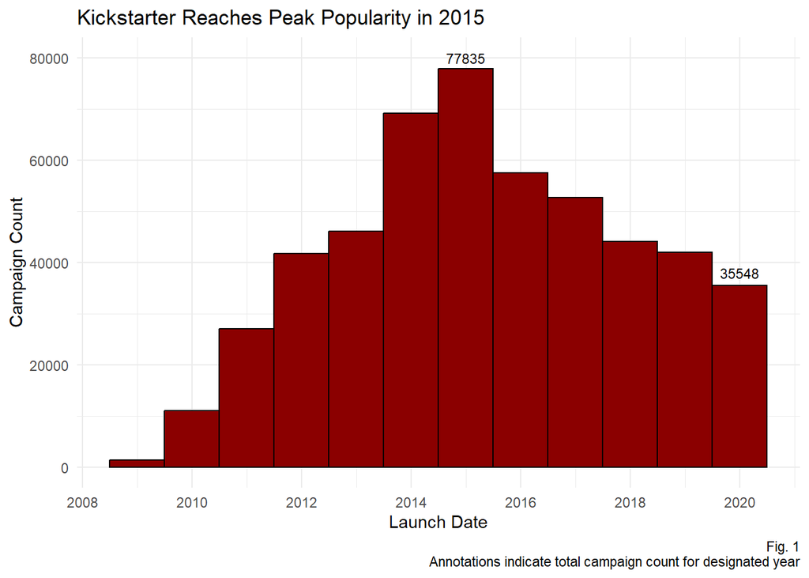

However, the total amount pledged (Fig. 2), as well as the amount pledged per campaign (Fig. 3), on Kickstarter peaked in 2020, despite having less than half of the total campaigns created in 2015. The proportion of amount pledged to total campaign count in 2020 is significantly larger than that of 2015, however, as the data set used in a census of all Kickstarter campaigns, this could be inflated by the large quantity of overall campaigns.

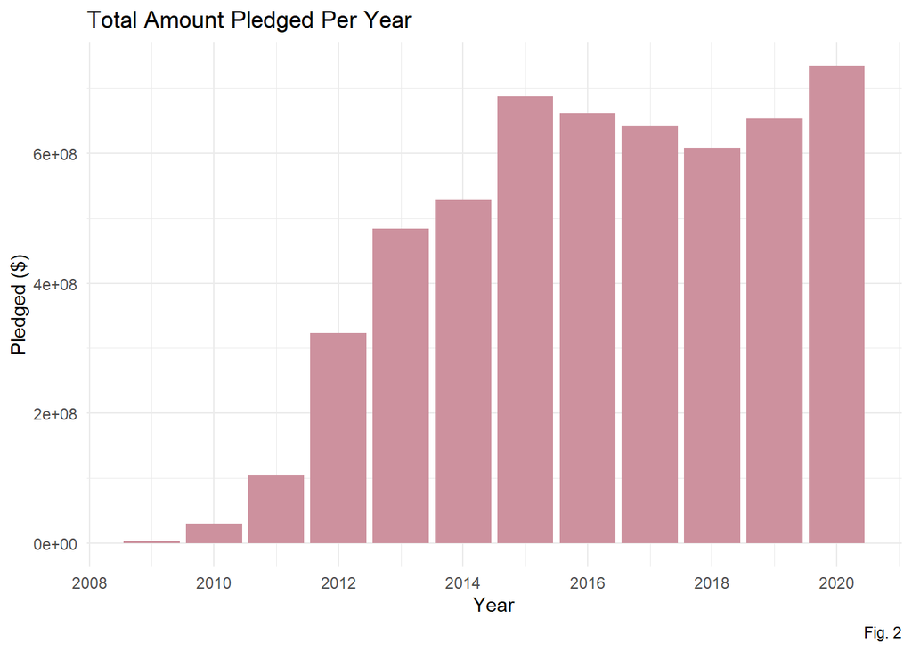

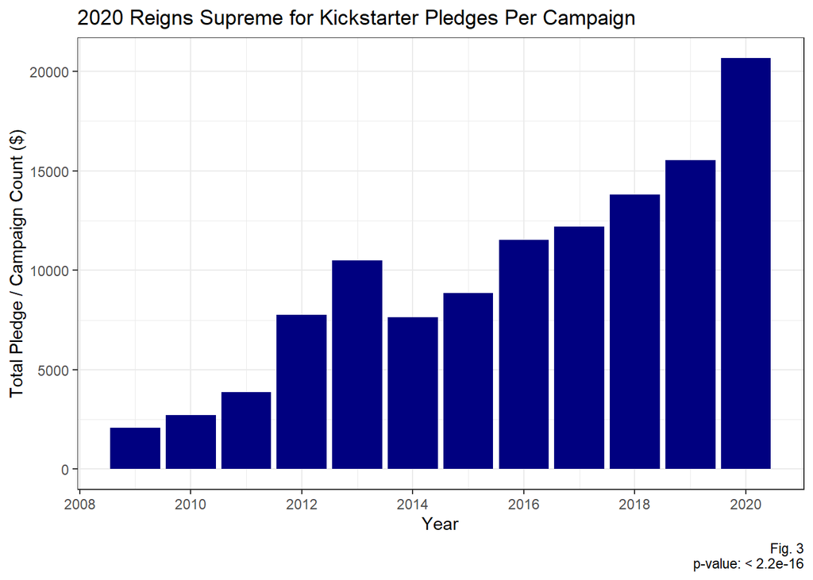

```
##
##  2-sample test for equality of proportions with continuity correction
##
## data:  c(77835, 35548) out of c(688278254, 734975580)
## X-squared = 18689, df = 1, p-value < 2.2e-16
## alternative hypothesis: greater
## 95 percent confidence interval:
##  6.39299e-05 1.00000e+00
## sample estimates:
##       prop 1       prop 2
## 1.130865e-04 4.836623e-05
```

With regard to campaign categories, results indicate that the most popular category on Kickstarter in total number of campaigns is Film & Video, and the least popular is Dance (Fig. 4).

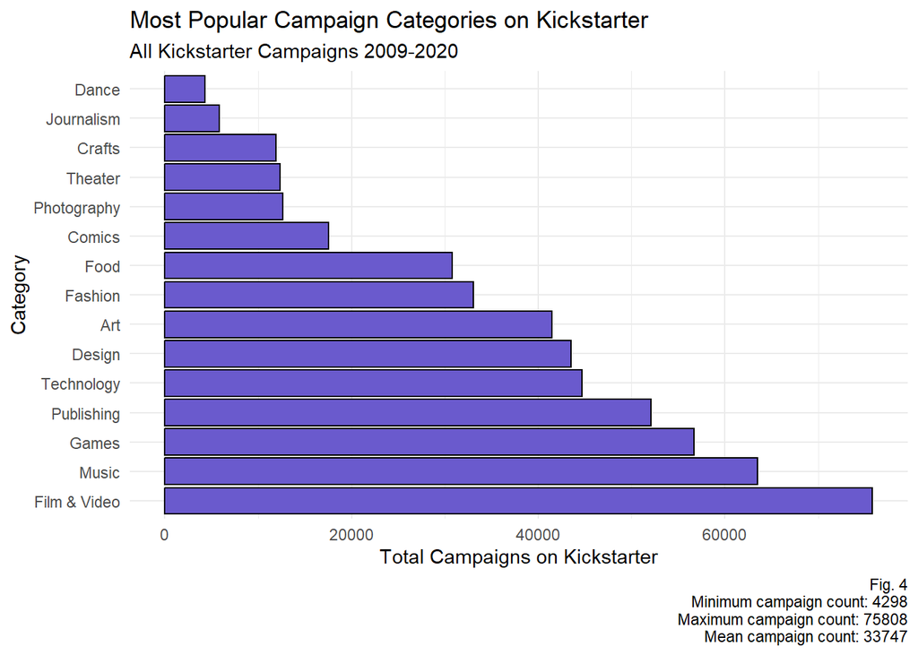

When analyzing the count of successful Kickstarter campaigns (Fig. 5), results indicate that Film & Video as well as Music are the most successful in terms of overall success count. Additionally, Journalism and Dance are the categories that have the least amount of successful campaigns.

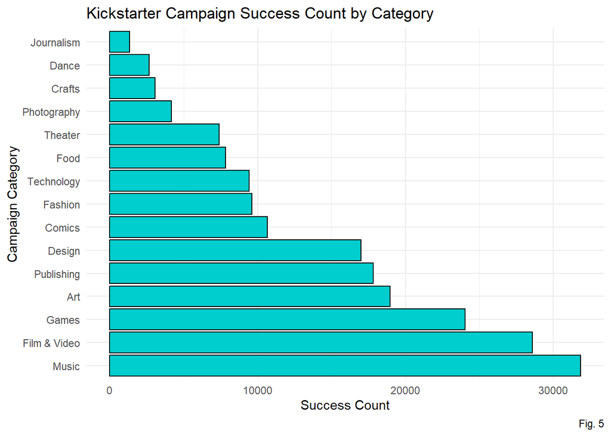

However, the fact that the categories with the highest number of successful campaigns are also those with the greatest number of total campaigns indicate that this should not be the only metric by which success is measured. For example, when investigating whether a correlation exists between total campaign number and success campaign count by category, a moderately strong linear correlation was observed (Fig. 6). 84.5% of the variance in campaign success can be explained by total campaign number. This relationship is also statistically significant with a p-value < 0.05 which means that overall campaign count has a strong effect on successful campaign count as would be expected.

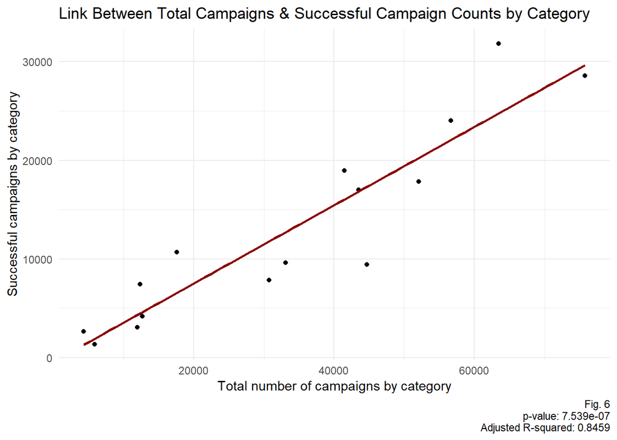

```
##
## Call:
## lm(formula = Successful ~ Count, data = ds2)
##
## Residuals:
##     Min      1Q  Median      3Q     Max
## -7889.5 -1824.6  -416.2  2444.4  7089.7
##
## Coefficients:
##               Estimate Std. Error t value Pr(>|t|)
## (Intercept) -426.64264 1805.33085  -0.236    0.817
## Count          0.39680    0.04497   8.823 7.54e-07 ***
## ---
## Signif. codes:  0 '***' 0.001 '**' 0.01 '*' 0.05 '.' 0.1 ' ' 1
##
## Residual standard error: 3786 on 13 degrees of freedom
## Multiple R-squared:  0.8569, Adjusted R-squared:  0.8459
## F-statistic: 77.84 on 1 and 13 DF,  p-value: 7.539e-07
```

Alternatively, results are also presented in the ratio of successful campaigns to the total number of campaigns in each category (Fig. 7). These results show a more standardized interpretation of true success rates, as for example, even though Dance had the fewest number of total campaigns and a low number of successful campaigns compared to other categories, the actual success rate of Dance demonstrates that it is the most successful category on Kickstarter with regard to percentage of total campaigns.

Success rates vary widely between categories, with a highest success rate of 0.62 and a lowest of 0.21. Further, a test to determine whether category has an effect on whether or not a campaign is successful (Chi-squared test of independence) indicated that success and failure rates are not independent of campaign category. This means that the chance of having a successful or failed campaign is dependent on which category the campaign is in.

[figure not shown]

```
##               status
## category       Failed Successful
##   Art           18710      18955
##   Comics         5529      10666
##   Crafts         7527       3061
##   Dance          1427       2650
##   Design        19949      17000
##   Fashion       19223       9615
##   Film & Video  39219      28597
##   Food          19744       7844
##   Games         22565      24028
##   Journalism     3765       1351
##   Music         26805      31854
##   Photography    7227       4175
##   Publishing    29066      17831
##   Technology    27855       9423
##   Theater        4187       7408
```

```
##
##  Pearson's Chi-squared test
##
## data:  tab
## X-squared = 22016, df = 14, p-value < 2.2e-16
```

These results prompted an investigation into how Kickstarter defines success. Successful Kickstarter campaigns are defined by a positive difference between the pledged amount and the goal amount, as shown in Figure 8.

When the proportion of successful campaigns and failed campaigns were examined, in relation to the total number of campaigns, the results show that Kickstarter had significantly more failed campaigns. The proportion of successful and failed campaigns were 0.38 and 0.5, respectively, which is a statistically significant difference. However, the statistical significance could potentially be inflated by the overall large scale of the data set itself.

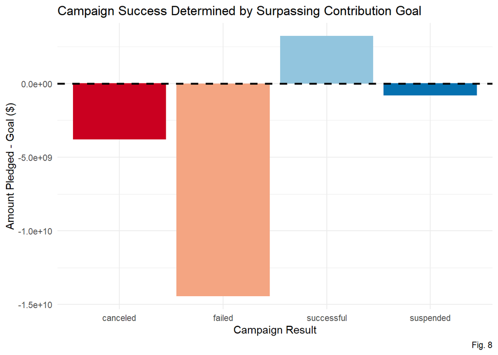

```
##
##  2-sample test for equality of proportions with continuity correction
##
## data:  c(194458, 252798) out of c(506199, 506199)
## X-squared = 13632, df = 1, p-value < 2.2e-16
## alternative hypothesis: two.sided
## 95 percent confidence interval:
##  -0.1171747 -0.1133275
## sample estimates:
##    prop 1    prop 2
## 0.3841533 0.4994044
```

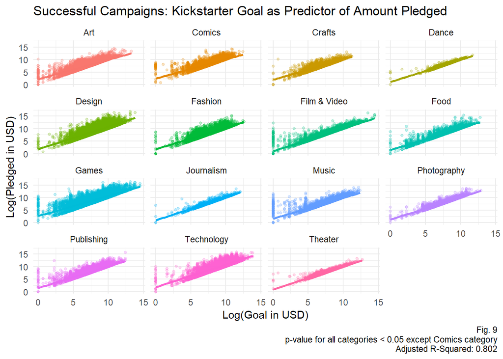

```
##
## Call:
## lm(formula = log(PLEDGED_IN_USD) ~ log(GOAL_IN_USD) * CATEGORY,
##     data = ds10)
##
## Residuals:
##     Min      1Q  Median      3Q     Max
## -2.6267 -0.3526 -0.1144  0.1535 11.1821
##
## Coefficients:
##                                        Estimate Std. Error t value Pr(>|t|)
## (Intercept)                            2.149272   0.024314  88.398  < 2e-16 ***
## log(GOAL_IN_USD)                       0.781441   0.003320 235.372  < 2e-16 ***
## CATEGORYComics                         0.253345   0.044110   5.743 9.29e-09 ***
## CATEGORYCrafts                        -0.234876   0.061039  -3.848 0.000119 ***
## CATEGORYDance                         -1.105577   0.107642 -10.271  < 2e-16 ***
## CATEGORYDesign                        -0.364694   0.038787  -9.402  < 2e-16 ***
## CATEGORYFashion                       -0.383564   0.042483  -9.029  < 2e-16 ***
## CATEGORYFilm & Video                  -1.151437   0.033876 -33.989  < 2e-16 ***
## CATEGORYFood                          -0.721120   0.046532 -15.497  < 2e-16 ***
## CATEGORYGames                          0.477381   0.032632  14.629  < 2e-16 ***
## CATEGORYJournalism                    -1.260796   0.095803 -13.160  < 2e-16 ***
## CATEGORYMusic                         -0.575865   0.035791 -16.089  < 2e-16 ***
## CATEGORYPhotography                   -0.965590   0.060800 -15.882  < 2e-16 ***
## CATEGORYPublishing                    -0.709645   0.039062 -18.167  < 2e-16 ***
## CATEGORYTechnology                    -0.385382   0.045652  -8.442  < 2e-16 ***
## CATEGORYTheater                       -1.331507   0.061895 -21.512  < 2e-16 ***
## log(GOAL_IN_USD):CATEGORYComics       -0.009096   0.005767  -1.577 0.114701
## log(GOAL_IN_USD):CATEGORYCrafts        0.038288   0.008602   4.451 8.56e-06 ***
## log(GOAL_IN_USD):CATEGORYDance         0.106700   0.013459   7.928 2.24e-15 ***
## log(GOAL_IN_USD):CATEGORYDesign        0.123767   0.004795  25.814  < 2e-16 ***
## log(GOAL_IN_USD):CATEGORYFashion       0.076454   0.005478  13.955  < 2e-16 ***
## log(GOAL_IN_USD):CATEGORYFilm & Video  0.123440   0.004339  28.450  < 2e-16 ***
## log(GOAL_IN_USD):CATEGORYFood          0.091143   0.005649  16.136  < 2e-16 ***
## log(GOAL_IN_USD):CATEGORYGames         0.031627   0.004227   7.482 7.36e-14 ***
## log(GOAL_IN_USD):CATEGORYJournalism    0.143723   0.011869  12.109  < 2e-16 ***
## log(GOAL_IN_USD):CATEGORYMusic         0.051639   0.004630  11.153  < 2e-16 ***
## log(GOAL_IN_USD):CATEGORYPhotography   0.113981   0.007703  14.798  < 2e-16 ***
## log(GOAL_IN_USD):CATEGORYPublishing    0.086507   0.005056  17.111  < 2e-16 ***
## log(GOAL_IN_USD):CATEGORYTechnology    0.127595   0.005368  23.769  < 2e-16 ***
## log(GOAL_IN_USD):CATEGORYTheater       0.135047   0.007910  17.074  < 2e-16 ***
## ---
## Signif. codes:  0 '***' 0.001 '**' 0.01 '*' 0.05 '.' 0.1 ' ' 1
##
## Residual standard error: 0.7121 on 194424 degrees of freedom
## Multiple R-squared:  0.8017, Adjusted R-squared:  0.8017
## F-statistic: 2.71e+04 on 29 and 194424 DF,  p-value: < 2.2e-16
```

## CONCLUSION

Results indicate that successful Kickstarter campaigns are those in which the amount pledged exceeds the goal set by the creator. Kickstarter has significantly more campaigns that fail to meet their goal than succeed in this endeavor. Additionally, the rate of success varies significantly depending on the category of the campaign. For example, Dance had the highest rate of success while technology had the lowest. Results also indicated that in successful campaigns, higher goals are strongly correlated with higher pledge amounts, but that this trend is not as strong for very high or very low goals.

Recommendations for anyone considering creating a Kickstarter campaign are numerous. First, category should be taken into account when starting a campaign, as success rates vary widely across categories. Second, results indicate that the monetary goal should be set at a moderate amount. The goal needs to be attainable for campaigns to be considered successful and to receive the pledge money. Additionally, results indicated that for successful campaigns goal amount is positively correlated with pledge amount, and that this is the most true for moderate goals that are not extremely low or extremely high. Therefore, goals should be attainable, but not too low.

## APPENDIX

2-proportion z-test assumptions: 1) np ≥ 10 & n(1-p) ≥ 10 (n sufficiently large): Use #1: This assumption is met as all samples are quite large Use #2: Met for the same reason as Use #1 2) Independence within and between groups: Use #1: Campaigns were either made in 2015, or 2020 (not both), so this is met. Additionally, one campaign being made in 2015 does not affect the chance of another being created in the same year. Therefore, this assumption is met. Use #2: A campaign can only succeed or fail, not both, so independence across groups is satisfied. Additionally, a campaign in one category succeeding does not affect the chances of success of another campaign in the same category. Therefore, this assumption is also met. 3) Sample can’t be more than 10% of population: Use #1: While the sample size is quite large, it is still safe to say that less than 10% of the global population has a Kickstarter campaign made between 2009 and 2020. Therefore, this assumption is also met Use #2: Met for the same reason as Use #1

```r
myTest$observed
```

```
##               status
## category       Failed Successful
##   Art           18710      18955
##   Comics         5529      10666
##   Crafts         7527       3061
##   Dance          1427       2650
##   Design        19949      17000
##   Fashion       19223       9615
##   Film & Video  39219      28597
##   Food          19744       7844
##   Games         22565      24028
##   Journalism     3765       1351
##   Music         26805      31854
##   Photography    7227       4175
##   Publishing    29066      17831
##   Technology    27855       9423
##   Theater        4187       7408
```

```r
myTest$expected
```

```
##               status
## category          Failed Successful
##   Art          21289.008  16375.992
##   Comics        9153.737   7041.263
##   Crafts        5984.549   4603.451
##   Dance         2304.402   1772.598
##   Design       20884.311  16064.689
##   Fashion      16299.812  12538.188
##   Film & Video 38330.954  29485.046
##   Food         15593.287  11994.713
##   Games        26335.292  20257.708
##   Journalism    2891.665   2224.335
##   Music        33155.235  25503.765
##   Photography   6444.638   4957.362
##   Publishing   26507.119  20389.881
##   Technology   21070.268  16207.732
##   Theater       6553.725   5041.275
```

Linear Regression / Multiple Linear Regression Assumptions Linear Regression Use: Linearity: Eye-ball tests shows points falling along the line of best fit to a reasonable degree given the relatively few data points, so this is met. Independent observations: This is met, while success may be more likely with a higher amount of campaigns, it is not inevitable / dependent on a high number of campaigns. Normally distributed errors/residuals: Points do not deviate significantly from the 45 degree line on the Q-Q plot. This is met. Equal variance for all X’s: Residuals and Scale-Location plot show points randomly scattered around the zero line, so this is met.

```r
#Linear Regression #1
summary(mod)
```

```
##
## Call:
## lm(formula = Successful ~ Count, data = ds2)
##
## Residuals:
##     Min      1Q  Median      3Q     Max
## -7889.5 -1824.6  -416.2  2444.4  7089.7
##
## Coefficients:
##               Estimate Std. Error t value Pr(>|t|)
## (Intercept) -426.64264 1805.33085  -0.236    0.817
## Count          0.39680    0.04497   8.823 7.54e-07 ***
## ---
## Signif. codes:  0 '***' 0.001 '**' 0.01 '*' 0.05 '.' 0.1 ' ' 1
##
## Residual standard error: 3786 on 13 degrees of freedom
## Multiple R-squared:  0.8569, Adjusted R-squared:  0.8459
## F-statistic: 77.84 on 1 and 13 DF,  p-value: 7.539e-07
```

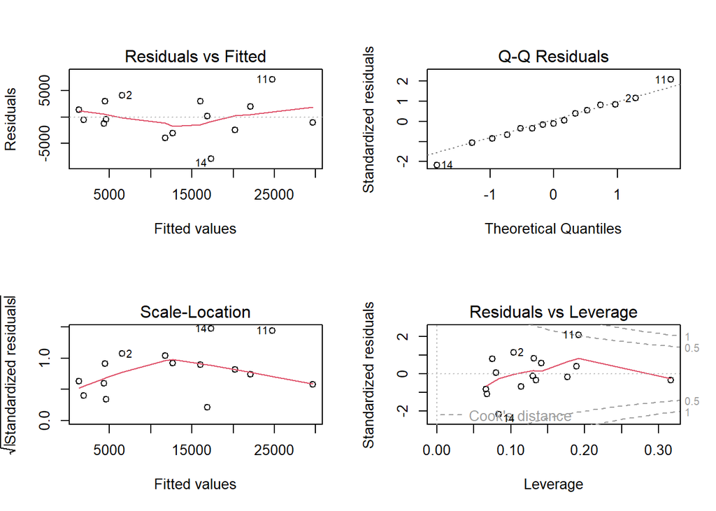

```r
par(mfrow=c(2,2))
plot(mod)
```

Linear Regression #2: Multiple Linear Regression Assumptions: Linearity: After logging both x and y variables, points fall closely along the linear line of best fit. Independent observations: Campaign goal and pledged amount are independent of each other, as one is determined by creators and the other is determined by backers. Normally distributed errors/residuals: Points fall closely along the line displayed in the Q-Q plot, however the model is less accurate at higher values. Equal variance for all X’s: Points seem to be fairly randomly clustered around the zero and one line on the residuals and scale-location plots respectively.

```r
#Linear Regression #2: Multiple Linear Regression
summary(logmod)
```

```
##
## Call:
## lm(formula = log(PLEDGED_IN_USD) ~ log(GOAL_IN_USD) * CATEGORY,
##     data = ds10)
##
## Residuals:
##     Min      1Q  Median      3Q     Max
## -2.6267 -0.3526 -0.1144  0.1535 11.1821
##
## Coefficients:
##                                        Estimate Std. Error t value Pr(>|t|)
## (Intercept)                            2.149272   0.024314  88.398  < 2e-16 ***
## log(GOAL_IN_USD)                       0.781441   0.003320 235.372  < 2e-16 ***
## CATEGORYComics                         0.253345   0.044110   5.743 9.29e-09 ***
## CATEGORYCrafts                        -0.234876   0.061039  -3.848 0.000119 ***
## CATEGORYDance                         -1.105577   0.107642 -10.271  < 2e-16 ***
## CATEGORYDesign                        -0.364694   0.038787  -9.402  < 2e-16 ***
## CATEGORYFashion                       -0.383564   0.042483  -9.029  < 2e-16 ***
## CATEGORYFilm & Video                  -1.151437   0.033876 -33.989  < 2e-16 ***
## CATEGORYFood                          -0.721120   0.046532 -15.497  < 2e-16 ***
## CATEGORYGames                          0.477381   0.032632  14.629  < 2e-16 ***
## CATEGORYJournalism                    -1.260796   0.095803 -13.160  < 2e-16 ***
## CATEGORYMusic                         -0.575865   0.035791 -16.089  < 2e-16 ***
## CATEGORYPhotography                   -0.965590   0.060800 -15.882  < 2e-16 ***
## CATEGORYPublishing                    -0.709645   0.039062 -18.167  < 2e-16 ***
## CATEGORYTechnology                    -0.385382   0.045652  -8.442  < 2e-16 ***
## CATEGORYTheater                       -1.331507   0.061895 -21.512  < 2e-16 ***
## log(GOAL_IN_USD):CATEGORYComics       -0.009096   0.005767  -1.577 0.114701
## log(GOAL_IN_USD):CATEGORYCrafts        0.038288   0.008602   4.451 8.56e-06 ***
## log(GOAL_IN_USD):CATEGORYDance         0.106700   0.013459   7.928 2.24e-15 ***
## log(GOAL_IN_USD):CATEGORYDesign        0.123767   0.004795  25.814  < 2e-16 ***
## log(GOAL_IN_USD):CATEGORYFashion       0.076454   0.005478  13.955  < 2e-16 ***
## log(GOAL_IN_USD):CATEGORYFilm & Video  0.123440   0.004339  28.450  < 2e-16 ***
## log(GOAL_IN_USD):CATEGORYFood          0.091143   0.005649  16.136  < 2e-16 ***
## log(GOAL_IN_USD):CATEGORYGames         0.031627   0.004227   7.482 7.36e-14 ***
## log(GOAL_IN_USD):CATEGORYJournalism    0.143723   0.011869  12.109  < 2e-16 ***
## log(GOAL_IN_USD):CATEGORYMusic         0.051639   0.004630  11.153  < 2e-16 ***
## log(GOAL_IN_USD):CATEGORYPhotography   0.113981   0.007703  14.798  < 2e-16 ***
## log(GOAL_IN_USD):CATEGORYPublishing    0.086507   0.005056  17.111  < 2e-16 ***
## log(GOAL_IN_USD):CATEGORYTechnology    0.127595   0.005368  23.769  < 2e-16 ***
## log(GOAL_IN_USD):CATEGORYTheater       0.135047   0.007910  17.074  < 2e-16 ***
## ---
## Signif. codes:  0 '***' 0.001 '**' 0.01 '*' 0.05 '.' 0.1 ' ' 1
##
## Residual standard error: 0.7121 on 194424 degrees of freedom
## Multiple R-squared:  0.8017, Adjusted R-squared:  0.8017
## F-statistic: 2.71e+04 on 29 and 194424 DF,  p-value: < 2.2e-16
```

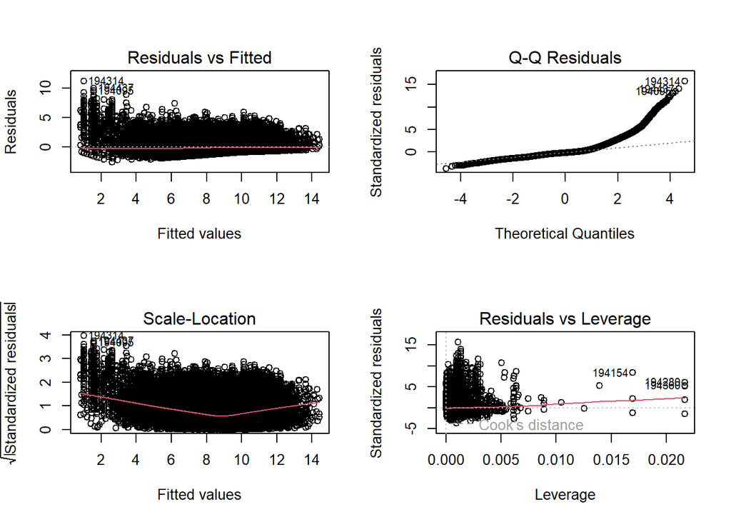

```r
par(mfrow=c(2,2))
plot(logmod)
```

## REFERENCES

Leland, Jonathan. Kickstarter Data, Global, 2009-2020. Inter-university Consortium for Political and Social Research [distributor], 2022-09-13. https://doi.org/10.3886/ICPSR38050.v2